# Reproducible Research: Peer Assessment 1

# Programming Assignment 1

## PART 1

```
by Prateek Sarangi, Mon , Mar  10:32:31
```

**Abstract:** This document represents the work for the **Programming Assignment 1** as  
part of **Reproducible esearch** online class offered by **Coursera**.

## 1.1 Loading and preprocessing the data

### 1.1.1 Read the raw data in R

```r
activity_raw <- read.csv("~/Downloads/Data/activity.csv")
```

### 1.1.2 Eliminate the rows which contains NAs

> > > This process is done in two steps: 1. Detect the rows that contain NAs  
> > > 2. Eliminate the rows with NAs( detected by step 1) from the raw data

```r
activity_with_na <- apply(activity_raw, 1, function(x){any(is.na(x))})
sum(activity_with_na)
```

```
## [1] 2304
```

```r
activity <- activity_raw[!activity_with_na, ]
```

> > > Verify that number of rows of clean data is  
> > > is equal to the difference between the number of rows of raw data and number  
> > > of rows with NA.

```r
    nrow(activity) == nrow(activity_raw) - sum(activity_with_na)
```

```
## [1] TRUE
```

### 1.1.4 Transform column “date” in a R “Date” type format

```r
typeof(activity$date)
```

```
## [1] "integer"
```

```r
head(activity)
```

```
##     steps       date interval
## 289     0 2012-10-02        0
## 290     0 2012-10-02        5
## 291     0 2012-10-02       10
## 292     0 2012-10-02       15
## 293     0 2012-10-02       20
## 294     0 2012-10-02       25
```

```r
activity$date <- as.character(activity$date)
activity$date <- as.Date(activity$date, format = '%Y-%m-%d')
head(activity)
```

```
##     steps       date interval
## 289     0 2012-10-02        0
## 290     0 2012-10-02        5
## 291     0 2012-10-02       10
## 292     0 2012-10-02       15
## 293     0 2012-10-02       20
## 294     0 2012-10-02       25
```

```r
tail(activity)
```

```
##       steps       date interval
## 17275     0 2012-11-29     2330
## 17276     0 2012-11-29     2335
## 17277     0 2012-11-29     2340
## 17278     0 2012-11-29     2345
## 17279     0 2012-11-29     2350
## 17280     0 2012-11-29     2355
```

```r
typeof(activity$date)
```

```
## [1] "double"
```

```r
data.class(activity$date)
```

```
## [1] "Date"
```

```r
summary(activity$date)
```

```
##         Min.      1st Qu.       Median         Mean      3rd Qu.         Max.
## "2012-10-02" "2012-10-16" "2012-10-29" "2012-10-30" "2012-11-16" "2012-11-29"
```

```r
start_rec <- min(activity$date)
end_rec <- max(activity$date)
(days_span <- end_rec - start_rec)
```

```
## Time difference of 58 days
```

```r
(number_days_rec <- length(levels(factor(activity$date))))
```

```
## [1] 53
```

> > > From a quick look into the date it can be observed that the span of recordings is over 58 days  
> > > but it does not guarantee that we have records for every single day between 2012-10-02 and 2012-11-29.  
> > > To find the actual number of days for which activity has been recorded, extract the number of levels  
> > > for table activity$date which is 53 days. Therefore, we have only 53 days with recorded actvity.

## 1.2. What is mean total number of steps taken per day?

### 1.2.1 Make a histogram of total number of stes taken each day

> > > - A new data frame has been build. It has two columns [dates, steps] and 53 rows corresponding  
> > >   to the number of days that were recorded.

```r
daily_steps <- data.frame(steps=numeric(0),
                date=as.Date(character()),
                stringsAsFactors=FALSE)
for (i in levels(factor(activity$date))) {
 new_vect <- c(sum(activity$steps[activity$date == i]), i)
# print(new_vect)
daily_steps[i, 1] <- sum(activity$steps[activity$date == i])
daily_steps[i, 2] <- i
}
rownames(daily_steps) <- c(1:nrow(daily_steps))
head(daily_steps)
```

```
##   steps       date
## 1   126 2012-10-02
## 2 11352 2012-10-03
## 3 12116 2012-10-04
## 4 13294 2012-10-05
## 5 15420 2012-10-06
## 6 11015 2012-10-07
```

> > > - Bellow is the histogram showing the frequency of number of steps per day.  
> > >   It is a quick overview of the distribution centered around 11000steps/day.

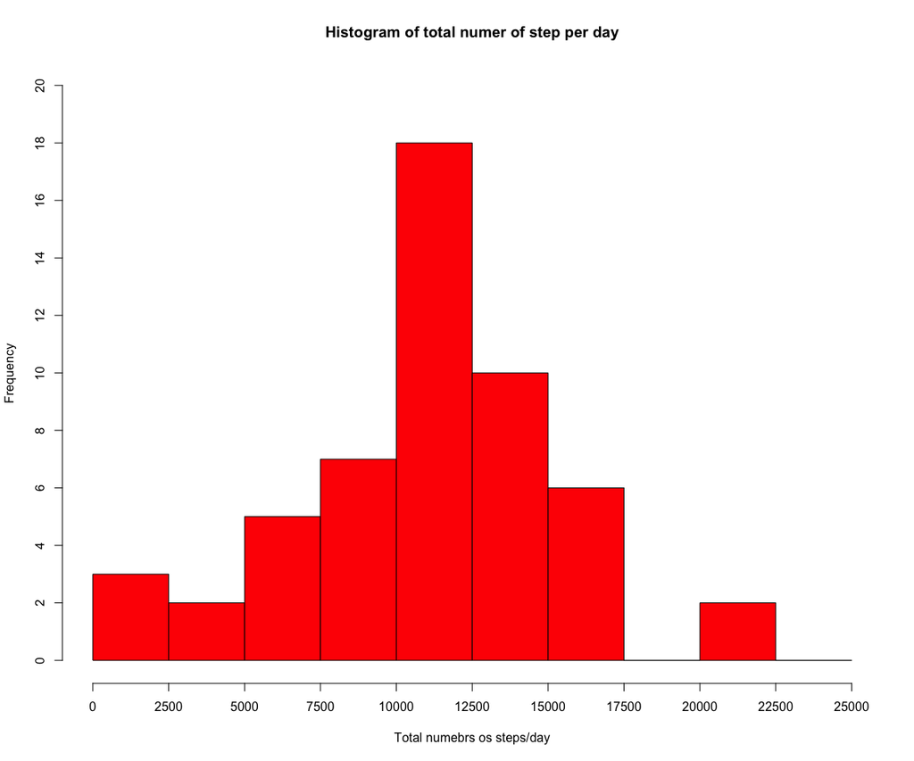

```r
hist(daily_steps$steps,
     col = "red",
     xlab = "Total numebrs os steps/day",
     main = "Histogram of total numer of step per day",
     breaks = seq(0, 25000, by = 2500),
     xlim = c(0, 25000),
     xaxp = c(0, 25000, 10),
     ylim = c(0, 20),
     yaxp = c(0, 20, 10)
)
```

```r
# dev.copy(png,'/Users/ashwini/RepData_PeerAssessment1/figures/histogram_of_steps_from_activity_without_NA.png')
# dev.off()
```

### 1.2.2 Calculate and report the mean and median total number of steps taken per day

```r
average_number_of_steps <- mean(daily_steps$steps)
median_of_daily_steps <- median(daily_steps$steps)
cat("Average number of steps per day is : ", average_number_of_steps)
```

```
## Average number of steps per day is :  10766.19
```

```r
cat("The median of number of steps per day is : ", median_of_daily_steps)
```

```
## The median of number of steps per day is :  10765
```

## 1.3 What is the average daily activity pattern?

### 1.3.1 Build a new table and calculate the average number of steps for each 5 minute interval across all recorded days

```r
average_per_interval <- data.frame(interval = numeric(length(levels(factor(activity$interval)))),
                                   average_steps_per_interval = numeric(length(levels(factor(activity$interval)))))
average_per_interval$interval = as.numeric(levels(factor(activity$interval)))
for(i in average_per_interval$interval){
average_per_interval[average_per_interval$interval == i, 2] <- mean(activity[activity$interval == i, ]$steps)
}
head(average_per_interval)
```

```
##   interval average_steps_per_interval
## 1        0                  1.7169811
## 2        5                  0.3396226
## 3       10                  0.1320755
## 4       15                  0.1509434
## 5       20                  0.0754717
## 6       25                  2.0943396
```

### 1.3.2 Plot the average of steps for each 5 minutes interval across all recorded days

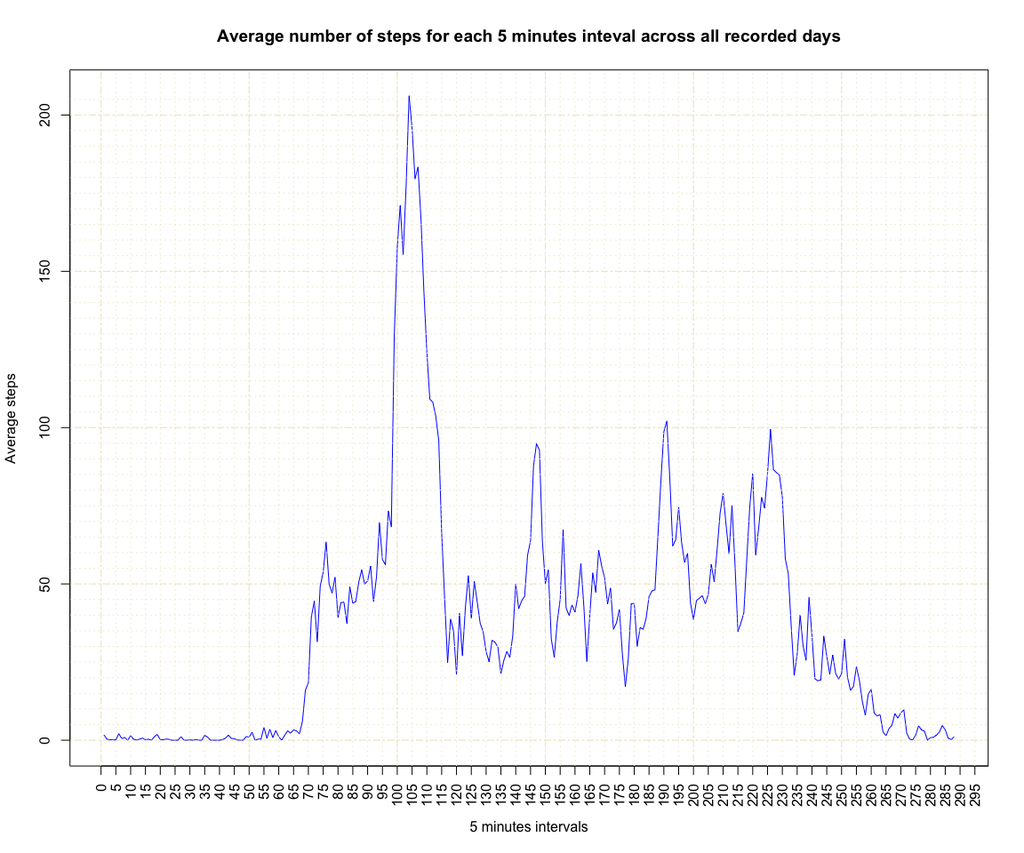

```r
plot(average_per_interval$average_steps_per_interval,
     xaxt = "n",
     type = "l",
     col = "blue",
     ylab = "Average steps",
     xlab = "5 minutes intervals",
     main = "Average number of steps for each 5 minutes inteval across all recorded days",
     panel.first = grid(nx = NULL, ny = NULL, lty = 6, col = "cornsilk2")
     )
axis(1,
     at=seq(min(average_per_interval$interval),
            max(average_per_interval$interval),
            5),
     las=2)
abline(v = seq(min(average_per_interval$interval),
            max(average_per_interval$interval),
            5),
       h = seq(min(average_per_interval$average_steps_per_interval),
            max(average_per_interval$average_steps_per_interval),
            5),
       col = "cornsilk2",
       lty = 3)
```

### 1.3.3 Which 5-minute interval, on average across all the days in the dataset, contains the maximum number of steps?

```r
max_step_index <- which(average_per_interval$average_steps_per_interval == max(c(average_per_interval$average_steps_per_interval)))
interval_num <- average_per_interval$interval[max_step_index]
cat("The 5-minutes interval containing the maximum number of steps, ", max(c(average_per_interval$average_steps_per_interval)), ", is ", interval_num, ".", sep = "")
```

```
## The 5-minutes interval containing the maximum number of steps, 206.1698, is 835.
```

**NOTE: This corresponds to 8:35AM.**

## PART 2

## 2.1 Imputing missing values

### 2.1.1 Calculate and report the total number of missing values in the dataset (i.e. the total number of rows with NAs)

```r
activity_with_na <- apply(activity_raw, 1, function(x){any(is.na(x))})
cat("Total number of rows with NAs is :", sum(activity_with_na))
```

```
## Total number of rows with NAs is : 2304
```

```r
activity_na <- activity_raw[which(activity_with_na == TRUE), ]
activity_na$steps <- round(average_per_interval$average_steps_per_interval)
head(activity_na)
```

```
##   steps       date interval
## 1     2 2012-10-01        0
## 2     0 2012-10-01        5
## 3     0 2012-10-01       10
## 4     0 2012-10-01       15
## 5     0 2012-10-01       20
## 6     2 2012-10-01       25
```

```r
tail(activity_na)
```

```
##       steps       date interval
## 17563     3 2012-11-30     2330
## 17564     5 2012-11-30     2335
## 17565     3 2012-11-30     2340
## 17566     1 2012-11-30     2345
## 17567     0 2012-11-30     2350
## 17568     1 2012-11-30     2355
```